# Equipo 4

# Promedo triangular

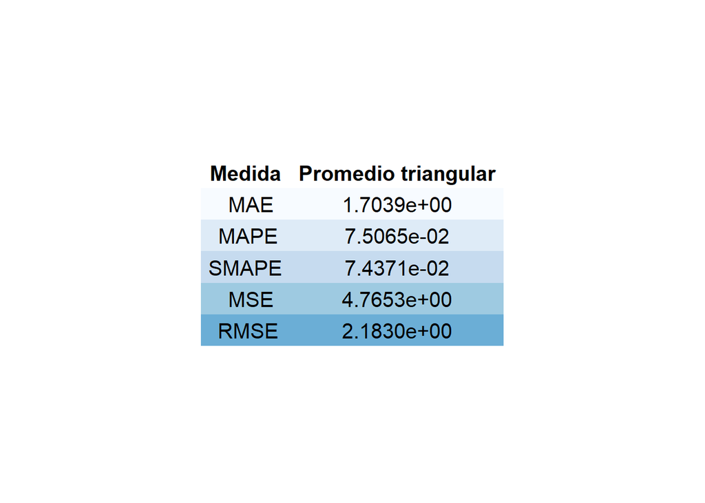

```r
tr <- movavg(tsTemp, 10, type = "t")

mae_PromTR<-MAE(tsTemp, tr)
mape_PromTR<-MAPE(tsTemp, tr)
smape_PromTR<-SMAPE(tsTemp, tr)
mse_PromTR<-MSE(tsTemp, tr)
rmse_PromTR<-RMSE(tsTemp, tr)
medidas_PromTR<-matrix(c(mae_PromTR,mape_PromTR,smape_PromTR,mse_PromTR,rmse_PromTR))
rownames(medidas_PromTR)<-c("MAE","MAPE","SMAPE","MSE","RMSE")
colnames(medidas_PromTR)<-c("Ponderada")
df_medidas_PromTR<-as.data.frame(medidas_PromTR)
tab_medidas_PromTR<-as.data.table(df_medidas_PromTR,keep.rownames=TRUE, keep.colnames=FALSE)
colnames(tab_medidas_PromTR)<-c("Medida","Promedio triangular")
ftab_medidas_PromTR<-format(tab_medidas_PromTR, digits=5,scientific=TRUE,big.mark=",",decimal.mark=".",small.mark=",",justify="right")
tem<-ttheme_minimal(base_colour = "black",base_size = 15,core=list(bg_params=list(fill=blues9,col=NA)))
grid.arrange(tableGrob(ftab_medidas_PromTR,theme=tem))
```

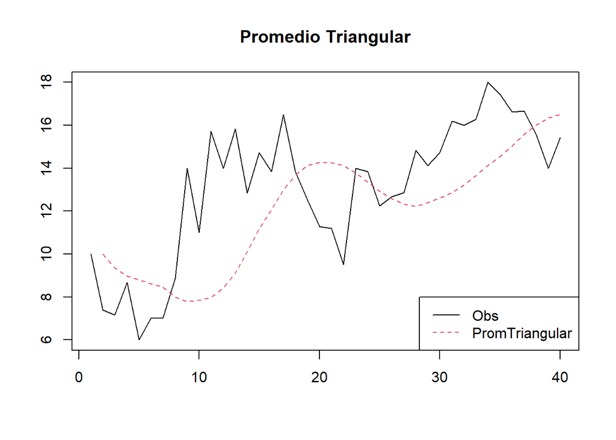

```r
fwt<-rep(0,40)
for(t in 2:40) fwt[t]<-tr[t-1]
for(t in 1) fwt[t]<-NA
fw_ts<-rep(0,19)
fw_ts<-ts(fwt,start=1,frequency=1)
ts.plot(tsTemp[0:40],fw_ts,xlab=NULL,ylab=NULL, main = "Promedio Triangular",lty=c(1:2),col=c(1,2))
legend(x="bottomright",legend=c("Obs","PromTriangular"),col=c(1,2),lty=c(1,2))
```

# Promedio modificado

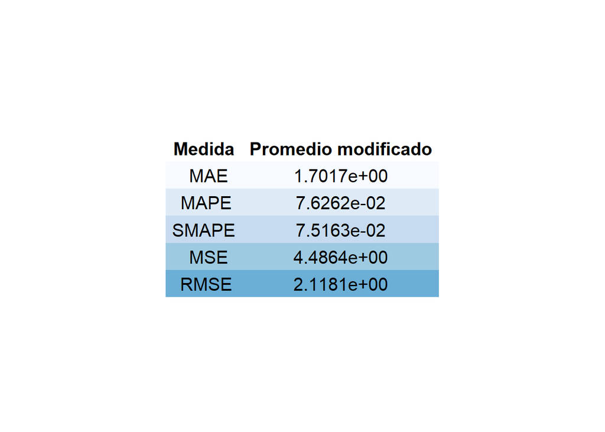

```r
m <- movavg(tsTemp, 10, type = "m")

mae_PromM<-MAE(tsTemp, m)
mape_PromM<-MAPE(tsTemp, m)
smape_PromM<-SMAPE(tsTemp, m)
mse_PromM<-MSE(tsTemp, m)
rmse_PromM<-RMSE(tsTemp, m)
medidas_PromM<-matrix(c(mae_PromM,mape_PromM,smape_PromM,mse_PromM,rmse_PromM))
rownames(medidas_PromM)<-c("MAE","MAPE","SMAPE","MSE","RMSE")
colnames(medidas_PromM)<-c("Ponderada")
df_medidas_PromM<-as.data.frame(medidas_PromM)
tab_medidas_PromM<-as.data.table(df_medidas_PromM,keep.rownames=TRUE, keep.colnames=FALSE)
colnames(tab_medidas_PromM)<-c("Medida","Promedio modificado")
ftab_medidas_PromM<-format(tab_medidas_PromM, digits=5,scientific=TRUE,big.mark=",",decimal.mark=".",small.mark=",",justify="right")
tem<-ttheme_minimal(base_colour = "black",base_size = 15,core=list(bg_params=list(fill=blues9,col=NA)))
grid.arrange(tableGrob(ftab_medidas_PromM,theme=tem))
```

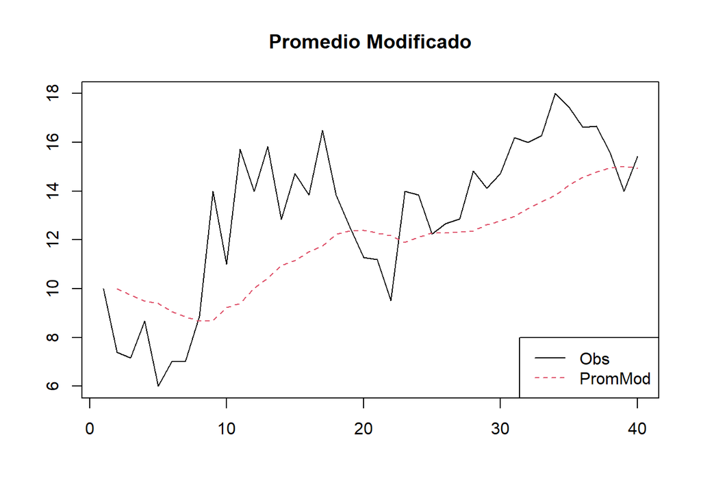

```r
fwt<-rep(0,40)
for(t in 2:40) fwt[t]<-m[t-1]
for(t in 1) fwt[t]<-NA
fw_ts<-rep(0,19)
fw_ts<-ts(fwt,start=1,frequency=1)
ts.plot(tsTemp[0:40],fw_ts,xlab=NULL,ylab=NULL, main = "Promedio Modificado",lty=c(1:2),col=c(1,2))
legend(x="bottomright",legend=c("Obs","PromMod"),col=c(1,2),lty=c(1,2))
```

Segun el comparativo de errores, el mejor pronostico nos lo va a dar el **Promedio Ponderado W**

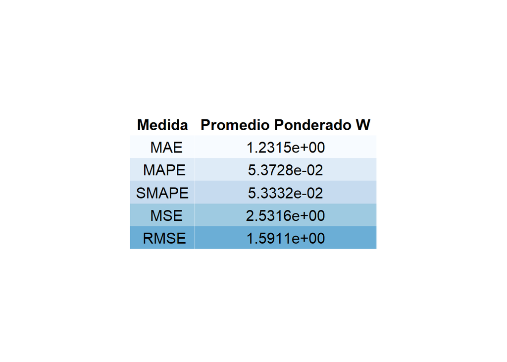

```r
fw <- movavg(tsTemp, 10, type = "w")

mae_PromW<-MAE(tsTemp, fw)
mape_PromW<-MAPE(tsTemp, fw)
smape_PromW<-SMAPE(tsTemp, fw)
mse_PromW<-MSE(tsTemp, fw)
rmse_PromW<-RMSE(tsTemp, fw)
medidas_PromW<-matrix(c(mae_PromW,mape_PromW,smape_PromW,mse_PromW,rmse_PromW))
rownames(medidas_PromW)<-c("MAE","MAPE","SMAPE","MSE","RMSE")
colnames(medidas_PromW)<-c("Ponderada W")
df_medidas_PromW<-as.data.frame(medidas_PromW)
tab_medidas_PromW<-as.data.table(df_medidas_PromW,keep.rownames=TRUE, keep.colnames=FALSE)
colnames(tab_medidas_PromW)<-c("Medida","Promedio Ponderado W")
ftab_medidas_PromW<-format(tab_medidas_PromW, digits=5,scientific=TRUE,big.mark=",",decimal.mark=".",small.mark=",",justify="right")
tem<-ttheme_minimal(base_colour = "black",base_size = 15,core=list(bg_params=list(fill=blues9,col=NA)))
grid.arrange(tableGrob(ftab_medidas_PromW,theme=tem))
```

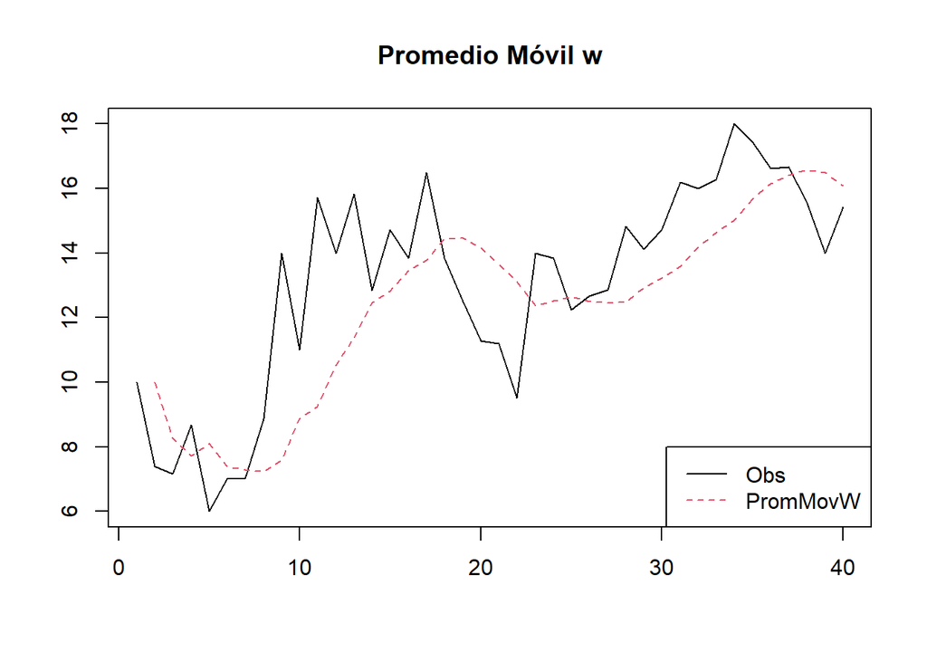

```r
fwt<-rep(0,40)
for(t in 2:40) fwt[t]<-fw[t-1]
for(t in 1) fwt[t]<-NA
fw_ts<-rep(0,19)
fw_ts<-ts(fwt,start=1,frequency=1)
ts.plot(tsTemp[0:40],fw_ts,xlab=NULL,ylab=NULL, main = "Promedio Móvil w",lty=c(1:2),col=c(1,2))
legend(x="bottomright",legend=c("Obs","PromMovW"),col=c(1,2),lty=c(1,2))
```

## Suavizamiento exponencial simple

### alpha = 0.1

```r
library(fpp2)
```

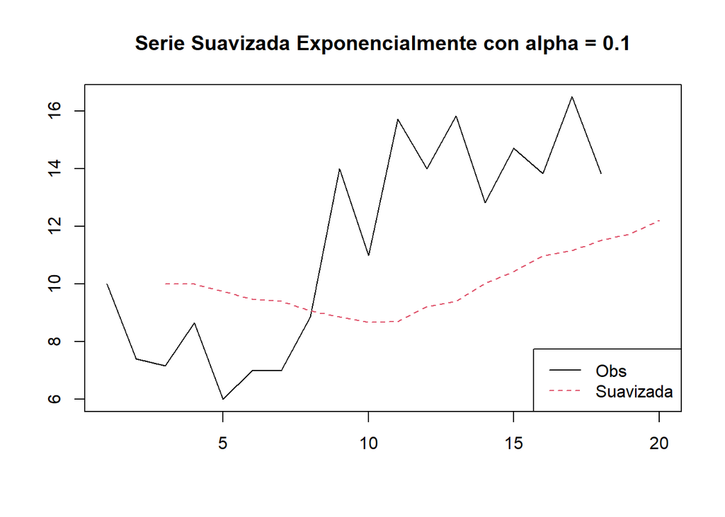

```r
est1<-ses(tsTemp, h = 2, level = c(95,95), initial = c("simple"), alpha = 0.1)
fse1<-est1$fitted
fse_ts1<-ts(fse1,start=1,frequency=1)
fset_ts1<-rep(0,20)
for(t in 3:20) fset_ts1[t]<-fse_ts1[t-2]
for(t in 1:2) fset_ts1[t]<-NA
yt1<-rep(0,20)
for(t in 1:18) yt1[t]<-tsTemp[t]
for(t in 19:20) yt1[t]<-NA
yt_ts1<-ts(yt1,start=1,frequency=1)
ts.plot(yt_ts1,fset_ts1,xlab=NULL,ylab=NULL, main = "Serie Suavizada Exponencialmente con alpha = 0.1",lty=c(1:2),col=c(1,2))
legend(x="bottomright",legend=c("Obs","Suavizada"),col=c(1,2),lty=c(1,2))
```

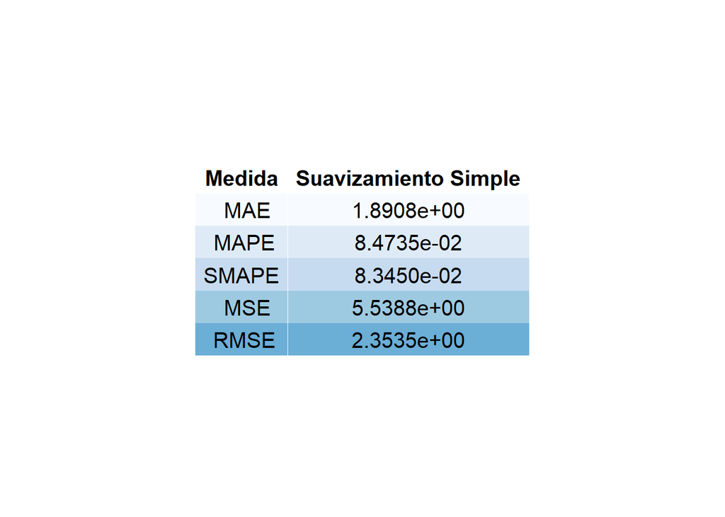

```r
mae_PromSS<-MAE(tsTemp, fse1)
mape_PromSS<-MAPE(tsTemp, fse1)
smape_PromSS<-SMAPE(tsTemp, fse1)
mse_PromSS<-MSE(tsTemp, fse1)
rmse_PromSS<-RMSE(tsTemp, fse1)
medidas_PromSS<-matrix(c(mae_PromSS,mape_PromSS,smape_PromSS,mse_PromSS,rmse_PromSS))
rownames(medidas_PromSS)<-c("MAE","MAPE","SMAPE","MSE","RMSE")
colnames(medidas_PromSS)<-c("Suavizamiento Simple")
df_medidas_PromSS<-as.data.frame(medidas_PromSS)
tab_medidas_PromSS<-as.data.table(df_medidas_PromSS,keep.rownames=TRUE, keep.colnames=FALSE)
colnames(tab_medidas_PromSS)<-c("Medida","Suavizamiento Simple")
ftab_medidas_PromSS<-format(tab_medidas_PromSS, digits=5,scientific=TRUE,big.mark=",",decimal.mark=".",small.mark=",",justify="right")
tem<-ttheme_minimal(base_colour = "black",base_size = 15,core=list(bg_params=list(fill=blues9,col=NA)))
grid.arrange(tableGrob(ftab_medidas_PromSS,theme=tem))
```

### $\alpha = 0.5$

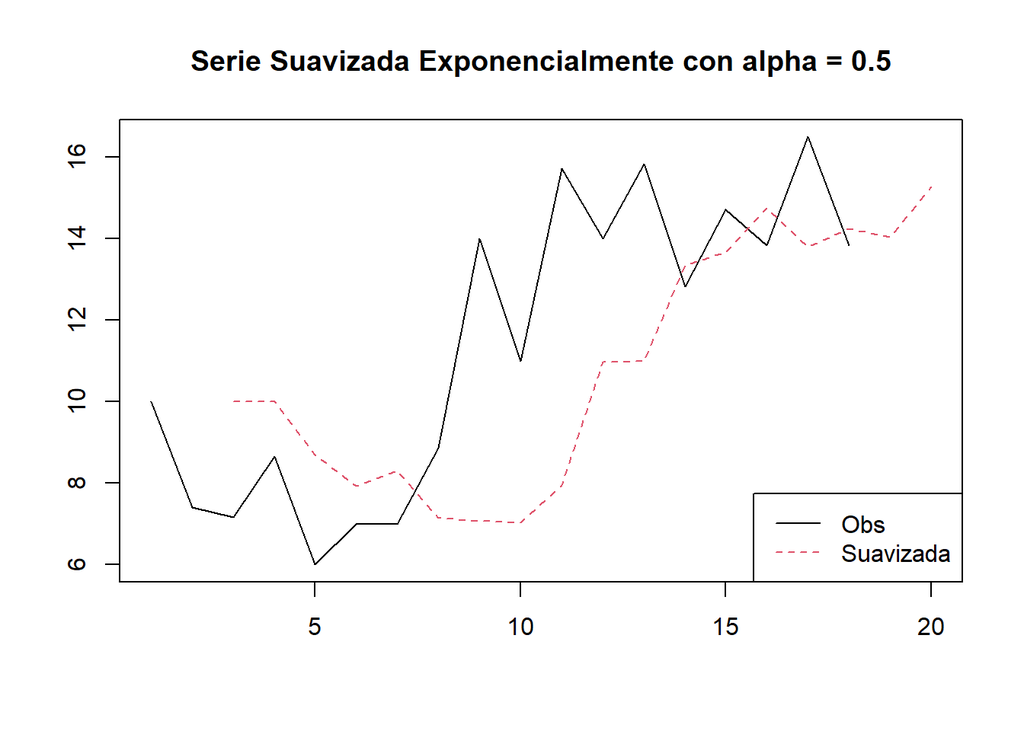

```r
est5<-ses(tsTemp, h = 2, level = c(95,95), initial = c("simple"), alpha = 0.5)
fse5<-est5$fitted
fse_ts5<-ts(fse5,start=1,frequency=1)
fset_ts5<-rep(0,20)
for(t in 3:20) fset_ts5[t]<-fse_ts5[t-2]
for(t in 1:2) fset_ts5[t]<-NA
yt5<-rep(0,20)
for(t in 1:18) yt5[t]<-tsTemp[t]
for(t in 19:20) yt5[t]<-NA
yt_ts5<-ts(yt5,start=1,frequency=1)
ts.plot(yt_ts5,fset_ts5,xlab=NULL,ylab=NULL, main = "Serie Suavizada Exponencialmente con alpha = 0.5",lty=c(1:2),col=c(1,2))
legend(x="bottomright",legend=c("Obs","Suavizada"),col=c(1,2),lty=c(1,2))
```

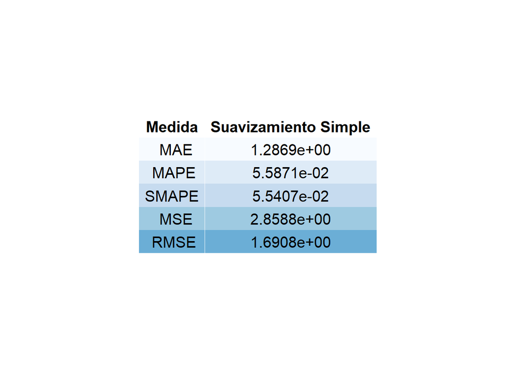

```r
mae_PromSS5<-MAE(tsTemp, fse5)
mape_PromSS5<-MAPE(tsTemp, fse5)
smape_PromSS5<-SMAPE(tsTemp, fse5)
mse_PromSS5<-MSE(tsTemp, fse5)
rmse_PromSS5<-RMSE(tsTemp, fse5)
medidas_PromSS5<-matrix(c(mae_PromSS5,mape_PromSS5,smape_PromSS5,mse_PromSS5,rmse_PromSS5))
rownames(medidas_PromSS5)<-c("MAE","MAPE","SMAPE","MSE","RMSE")
colnames(medidas_PromSS5)<-c("Suavizamiento Simple")
df_medidas_PromSS5<-as.data.frame(medidas_PromSS5)
tab_medidas_PromSS5<-as.data.table(df_medidas_PromSS5,keep.rownames=TRUE, keep.colnames=FALSE)
colnames(tab_medidas_PromSS5)<-c("Medida","Suavizamiento Simple")
ftab_medidas_PromSS5<-format(tab_medidas_PromSS5, digits=5,scientific=TRUE,big.mark=",",decimal.mark=".",small.mark=",",justify="right")
tem<-ttheme_minimal(base_colour = "black",base_size = 15,core=list(bg_params=list(fill=blues9,col=NA)))
grid.arrange(tableGrob(ftab_medidas_PromSS5,theme=tem))
```

### $\alpha = 0.8$

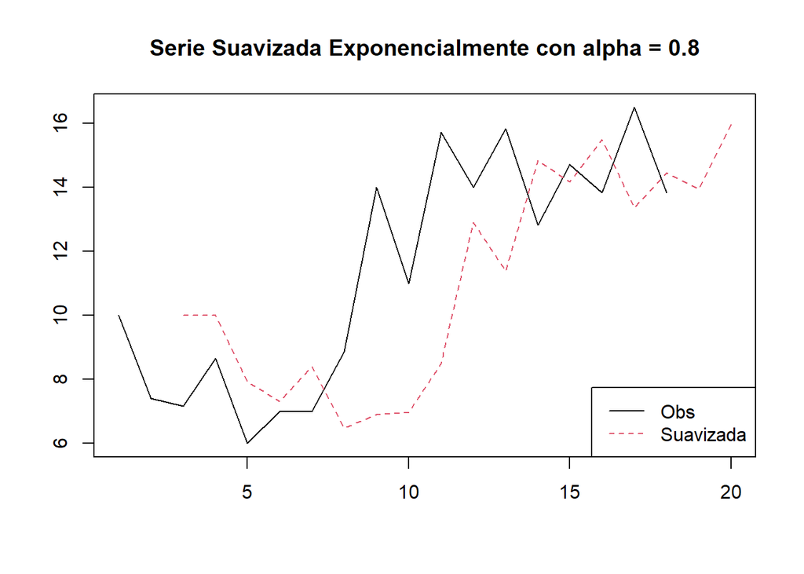

```r
est8<-ses(tsTemp, h = 2, level = c(95,95), initial = c("simple"), alpha = 0.8)
fse8<-est8$fitted
fse_ts8<-ts(fse8,start=1,frequency=1)
fset_ts8<-rep(0,20)
for(t in 3:20) fset_ts8[t]<-fse_ts8[t-2]
for(t in 1:2) fset_ts8[t]<-NA
yt8<-rep(0,20)
for(t in 1:18) yt8[t]<-tsTemp[t]
for(t in 19:20) yt8[t]<-NA
yt_ts8<-ts(yt8,start=1,frequency=1)
ts.plot(yt_ts8,fset_ts8,xlab=NULL,ylab=NULL, main = "Serie Suavizada Exponencialmente con alpha = 0.8",lty=c(1:2),col=c(1,2))
legend(x="bottomright",legend=c("Obs","Suavizada"),col=c(1,2),lty=c(1,2))
```

```r
mae_PromSS8<-MAE(tsTemp, fse8)
mape_PromSS8<-MAPE(tsTemp, fse8)
smape_PromSS8<-SMAPE(tsTemp, fse8)
mse_PromSS8<-MSE(tsTemp, fse8)
rmse_PromSS8<-RMSE(tsTemp, fse8)
medidas_PromSS8<-matrix(c(mae_PromSS8,mape_PromSS8,smape_PromSS8,mse_PromSS8,rmse_PromSS8))
rownames(medidas_PromSS8)<-c("MAE","MAPE","SMAPE","MSE","RMSE")
colnames(medidas_PromSS8)<-c("Suavizamiento Simple")
df_medidas_PromSS8<-as.data.frame(medidas_PromSS8)
tab_medidas_PromSS8<-as.data.table(df_medidas_PromSS8,keep.rownames=TRUE, keep.colnames=FALSE)
colnames(tab_medidas_PromSS8)<-c("Medida","Suavizamiento Simple")
ftab_medidas_PromSS8<-format(tab_medidas_PromSS8, digits=5,scientific=TRUE,big.mark=",",decimal.mark=".",small.mark=",",justify="right")
tem<-ttheme_minimal(base_colour = "black",base_size = 15,core=list(bg_params=list(fill=blues9,col=NA)))
grid.arrange(tableGrob(ftab_medidas_PromSS8,theme=tem))
```

[output not shown]

## Suavizamiento exponencial ajustado por la tendencia (Brown)

### $\alpha = 0.1$

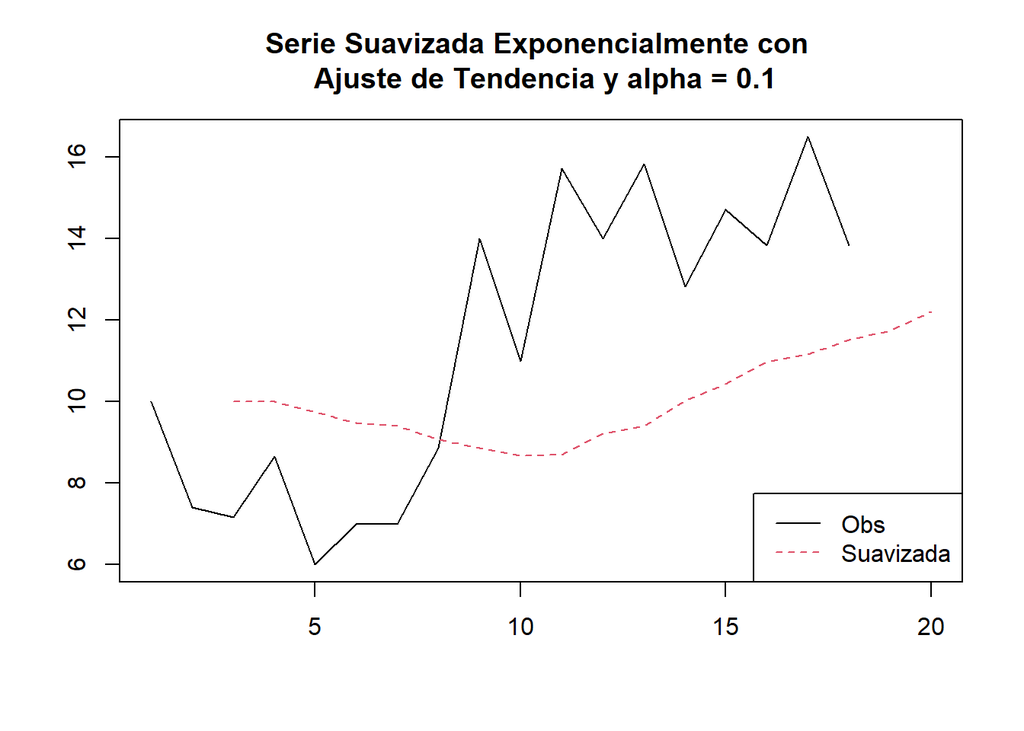

```r
estr<-ses(tsTemp, h = 2, level = c(95, 95), initial = c("simple"),  alpha = 0.1, exponential = TRUE, beta = NULL)
fser<-estr$fitted
fser_ts<-ts(fser,start=1,frequency=1)
fsetr_ts<-rep(0,20)
for(t in 3:20) fsetr_ts[t]<-fser_ts[t-2]
for(t in 1:2) fsetr_ts[t]<-NA
yt<-rep(0,20)
for(t in 1:18) yt[t]<- tsTemp[t]
for(t in 19:20) yt[t]<-NA
yt_ts<-ts(yt,start=1,frequency=1)
ts.plot(yt_ts,fsetr_ts,xlab=NULL,ylab=NULL, main = "Serie Suavizada Exponencialmente con \n Ajuste de Tendencia y alpha = 0.1",lty=c(1:2),col=c(1,2))
legend(x="bottomright",legend=c("Obs","Suavizada"),col=c(1,2),lty=c(1,2))
```

```r
mae_PromSE<-MAE(tsTemp, fser)
mape_PromSE<-MAPE(tsTemp, fser)
smape_PromSE<-SMAPE(tsTemp, fser)
mse_PromSE<-MSE(tsTemp, fser)
rmse_PromSE<-RMSE(tsTemp, fser)
medidas_PromSE<-matrix(c(mae_PromSE,mape_PromSE,smape_PromSE,mse_PromSE,rmse_PromSE))
rownames(medidas_PromSE)<-c("MAE","MAPE","SMAPE","MSE","RMSE")
colnames(medidas_PromSE)<-c("Suavizamiento Exponencial")
df_medidas_PromSE<-as.data.frame(medidas_PromSE)
tab_medidas_PromSE<-as.data.table(df_medidas_PromSE,keep.rownames=TRUE, keep.colnames=FALSE)
colnames(tab_medidas_PromSE)<-c("Medida","Suavizamiento Simple")
ftab_medidas_PromSE<-format(tab_medidas_PromSS8, digits=5,scientific=TRUE,big.mark=",",decimal.mark=".",small.mark=",",justify="right")
tem<-ttheme_minimal(base_colour = "black",base_size = 15,core=list(bg_params=list(fill=blues9,col=NA)))
grid.arrange(tableGrob(ftab_medidas_PromSE,theme=tem))
```

[output not shown]

### $\alpha = 0.5$

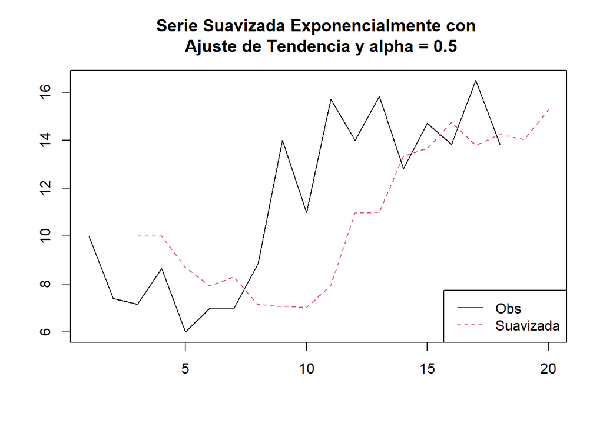

```r
estr5<-ses(tsTemp, h = 2, level = c(95, 95), initial = c("simple"),  alpha = 0.5, exponential = TRUE, beta = NULL)
fser5<-estr5$fitted
fser_ts5<-ts(fser5,start=1,frequency=1)
fsetr_ts5<-rep(0,20)
for(t in 3:20) fsetr_ts5[t]<-fser_ts5[t-2]
for(t in 1:2) fsetr_ts5[t]<-NA
yt5<-rep(0,20)
for(t in 1:18) yt5[t]<- tsTemp[t]
for(t in 19:20) yt5[t]<-NA
yt_ts5<-ts(yt5,start=1,frequency=1)
ts.plot(yt_ts5,fsetr_ts5,xlab=NULL,ylab=NULL, main = "Serie Suavizada Exponencialmente con \n Ajuste de Tendencia y alpha = 0.5",lty=c(1:2),col=c(1,2))
legend(x="bottomright",legend=c("Obs","Suavizada"),col=c(1,2),lty=c(1,2))
```

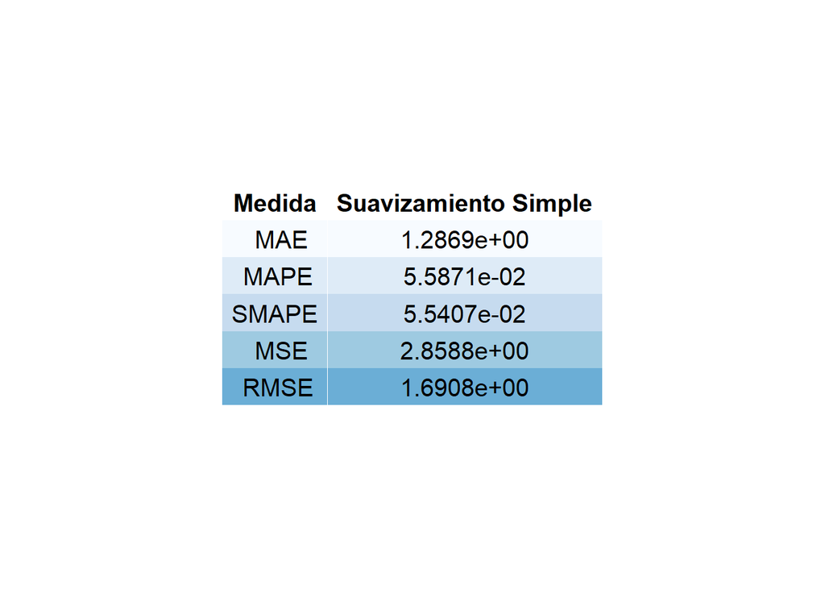

```r
mae_PromSE5<-MAE(tsTemp, fser5)
mape_PromSE5<-MAPE(tsTemp, fser5)
smape_PromSE5<-SMAPE(tsTemp, fser5)
mse_PromSE5<-MSE(tsTemp, fser5)
rmse_PromSE5<-RMSE(tsTemp, fser5)
medidas_PromSE5<-matrix(c(mae_PromSE5,mape_PromSE5,smape_PromSE5,mse_PromSE5,rmse_PromSE5))
rownames(medidas_PromSE5)<-c("MAE","MAPE","SMAPE","MSE","RMSE")
colnames(medidas_PromSE5)<-c("Suavizamiento Exponencial")
df_medidas_PromSE5<-as.data.frame(medidas_PromSE5)
tab_medidas_PromSE5<-as.data.table(df_medidas_PromSE5,keep.rownames=TRUE, keep.colnames=FALSE)
colnames(tab_medidas_PromSE5)<-c("Medida","Suavizamiento Simple")
ftab_medidas_PromSE5<-format(tab_medidas_PromSE5, digits=5,scientific=TRUE,big.mark=",",decimal.mark=".",small.mark=",",justify="right")
tem<-ttheme_minimal(base_colour = "black",base_size = 15,core=list(bg_params=list(fill=blues9,col=NA)))
grid.arrange(tableGrob(ftab_medidas_PromSE5,theme=tem))
```

### $\alpha = 0.8$

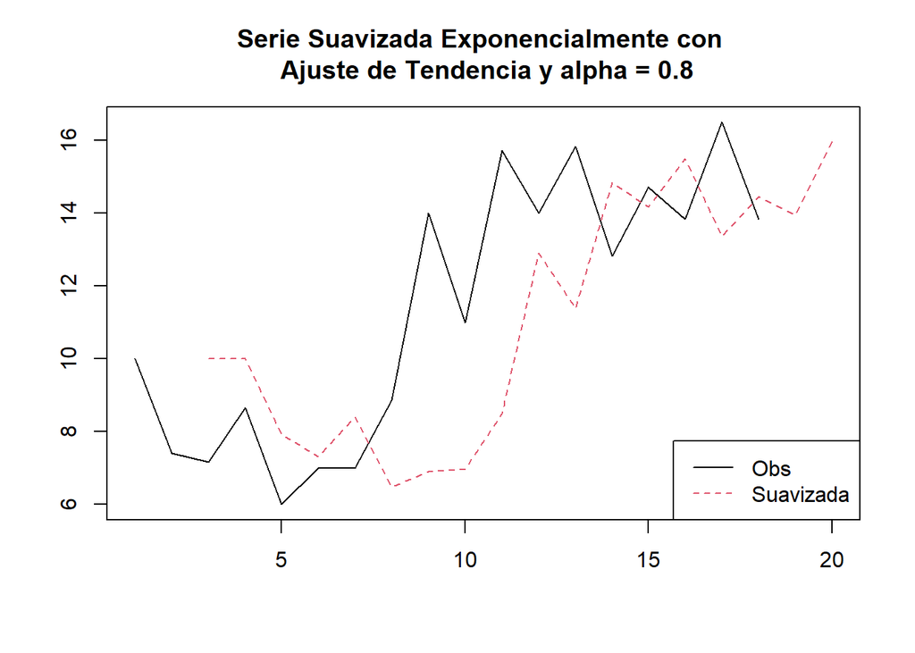

```r
estr8<-ses(tsTemp, h = 2, level = c(95, 95), initial = c("simple"),  alpha = 0.8, exponential = TRUE, beta = NULL)
fser8<-estr8$fitted
fser_ts8<-ts(fser8,start=1,frequency=1)
fsetr_ts8<-rep(0,20)
for(t in 3:20) fsetr_ts8[t]<-fser_ts8[t-2]
for(t in 1:2) fsetr_ts8[t]<-NA
yt8<-rep(0,20)
for(t in 1:18) yt8[t]<- tsTemp[t]
for(t in 19:20) yt8[t]<-NA
yt_ts8<-ts(yt8,start=1,frequency=1)
ts.plot(yt_ts8,fsetr_ts8,xlab=NULL,ylab=NULL, main = "Serie Suavizada Exponencialmente con \n Ajuste de Tendencia y alpha = 0.8",lty=c(1:2),col=c(1,2))
legend(x="bottomright",legend=c("Obs","Suavizada"),col=c(1,2),lty=c(1,2))
```

```r
mae_PromSE8<-MAE(tsTemp, fser8)
mape_PromSE8<-MAPE(tsTemp, fser8)
smape_PromSE8<-SMAPE(tsTemp, fser8)
mse_PromSE8<-MSE(tsTemp, fser8)
rmse_PromSE8<-RMSE(tsTemp, fser8)
medidas_PromSE8<-matrix(c(mae_PromSE8,mape_PromSE8,smape_PromSE8,mse_PromSE8,rmse_PromSE8))
rownames(medidas_PromSE8)<-c("MAE","MAPE","SMAPE","MSE","RMSE")
colnames(medidas_PromSE8)<-c("Suavizamiento Exponencial")
df_medidas_PromSE8<-as.data.frame(medidas_PromSE8)
tab_medidas_PromSE8<-as.data.table(df_medidas_PromSE8,keep.rownames=TRUE, keep.colnames=FALSE)
colnames(tab_medidas_PromSE8)<-c("Medida","Suavizamiento Simple")
ftab_medidas_PromSE8<-format(tab_medidas_PromSE8, digits=5,scientific=TRUE,big.mark=",",decimal.mark=".",small.mark=",",justify="right")
tem<-ttheme_minimal(base_colour = "black",base_size = 15,core=list(bg_params=list(fill=blues9,col=NA)))
grid.arrange(tableGrob(ftab_medidas_PromSE8,theme=tem))
```

[output not shown]

El suavizado exponencial con ajuste de tendencia con $=$0.8 es el mejor debido a que se ajusta mejor y presenta errores más bajos.

## Holt

Este método suaviza de forma directa la tendencia y la pendiente

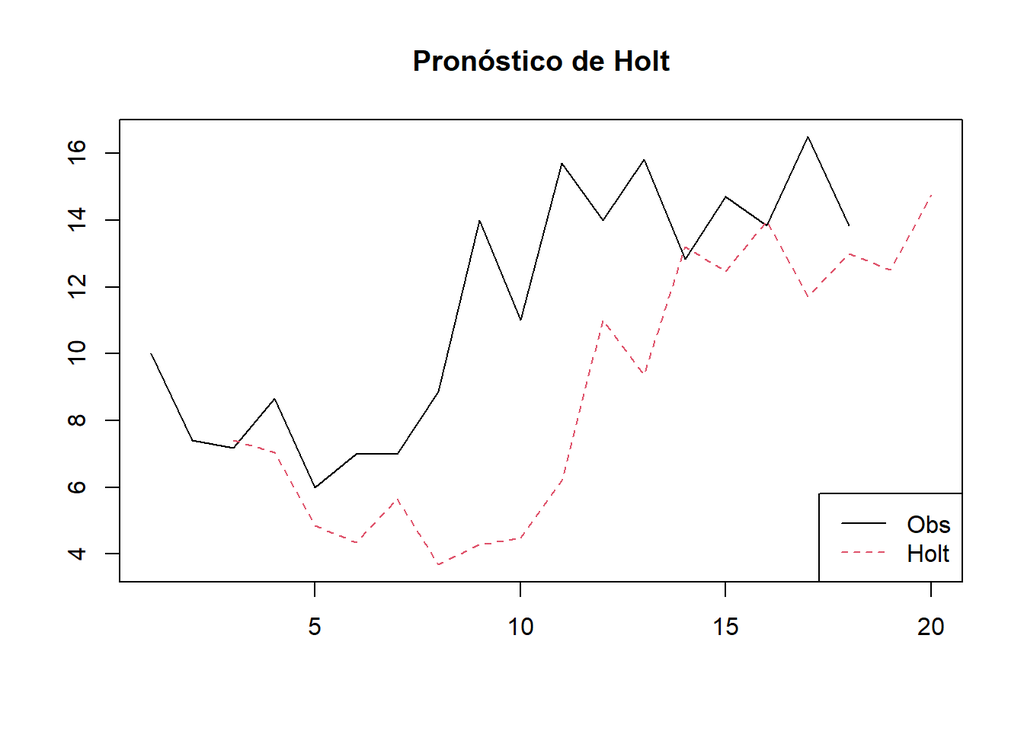

```r
esth<-holt(tsTemp, h = 10, level = c(0.95, 0.95), initial = c("simple"),  alpha = NULL, beta = NULL)
fh<-esth$fitted
fh_ts<-ts(fh,start=1,frequency=1)
fht_ts<-rep(0,20)
for(t in 3:20) fht_ts[t]<-fh_ts[t-2]
for(t in 1:2) fht_ts[t]<-NA
yt<-rep(0,20)
for(t in 1:18) yt[t]<-tsTemp[t]
for(t in 19:20) yt[t]<-NA
yt_ts<-ts(yt,start=1,frequency=1)
ts.plot(yt_ts,fht_ts,xlab=NULL,ylab=NULL, main = "Pronóstico de Holt",lty=c(1:2),col=c(1,2))
legend(x="bottomright",legend=c("Obs","Holt"),col=c(1,2),lty=c(1,2))
```

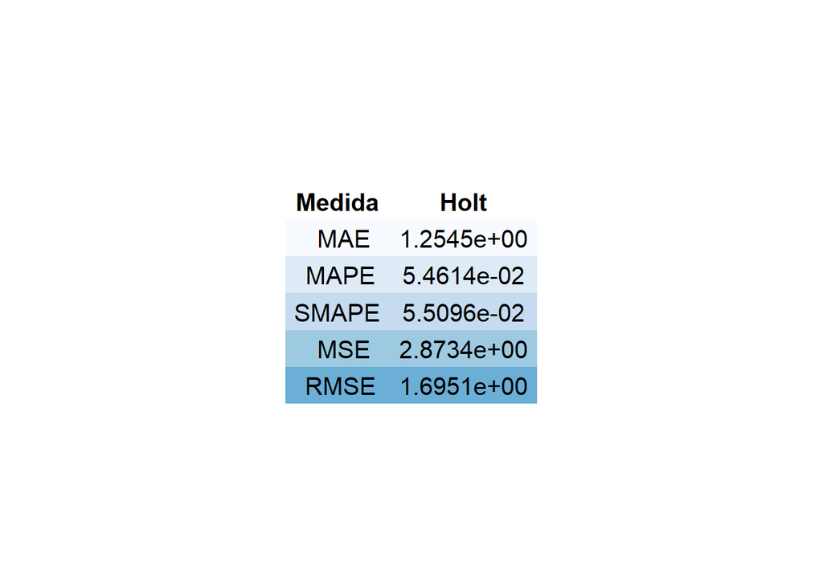

```r
mae_PromFH<-MAE(tsTemp, fh)
mape_PromFH<-MAPE(tsTemp, fh)
smape_PromFH<-SMAPE(tsTemp, fh)
mse_PromFH<-MSE(tsTemp, fh)
rmse_PromFH<-RMSE(tsTemp, fh)
medidas_PromFH<-matrix(c(mae_PromFH,mape_PromFH,smape_PromFH,mse_PromFH,rmse_PromFH))
rownames(medidas_PromFH)<-c("MAE","MAPE","SMAPE","MSE","RMSE")
colnames(medidas_PromFH)<-c("Holt")
df_medidas_PromFH<-as.data.frame(medidas_PromFH)
tab_medidas_PromFH<-as.data.table(df_medidas_PromFH,keep.rownames=TRUE, keep.colnames=FALSE)
colnames(tab_medidas_PromFH)<-c("Medida","Holt")
ftab_medidas_PromFH<-format(tab_medidas_PromFH, digits=5,scientific=TRUE,big.mark=",",decimal.mark=".",small.mark=",",justify="right")
tem<-ttheme_minimal(base_colour = "black",base_size = 15,core=list(bg_params=list(fill=blues9,col=NA)))
grid.arrange(tableGrob(ftab_medidas_PromFH,theme=tem))
```

## Holt Winters Multiplicativo

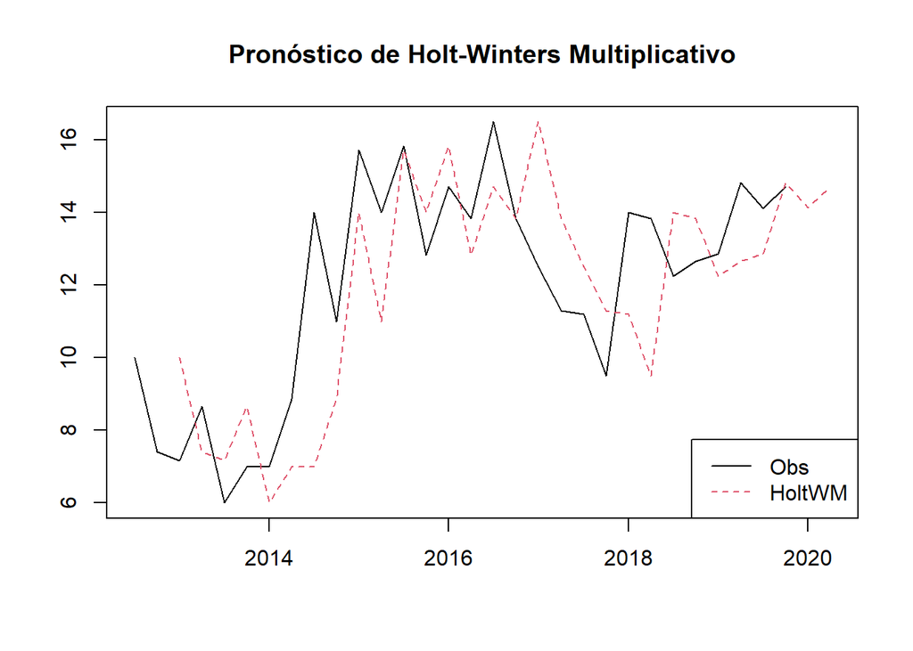

```r
est_hwm<-hw(tsTemp, h = 2, seasonal = c("multiplicative"),level = c(80, 95),initial = c("simple"), alpha = NULL, beta = NULL, gamma = NULL)
fhwm<-est_hwm$fitted
fhwm_ts<-ts(fhwm,start=c(2012,3),frequency=4)
fhwmt_ts<-rep(0,32)
for(t in 3:32) fhwmt_ts[t]<-fhwm_ts[t-2]
for(t in 1:2) fhwmt_ts[t]<-NA
yt<-rep(0,32)
for(t in 1:30) yt[t]<-tsTemp[t]
for(t in 31:32) yt[t]<-NA
yt_ts<-ts(yt,start=c(2012,3),frequency=4)
ts.plot(yt_ts,fhwmt_ts,xlab=NULL,ylab=NULL, main = "Pronóstico de Holt-Winters Multiplicativo",lty=c(1:2),col=c(1,2))
legend(x="bottomright",legend=c("Obs","HoltWM"),col=c(1,2),lty=c(1,2))
```

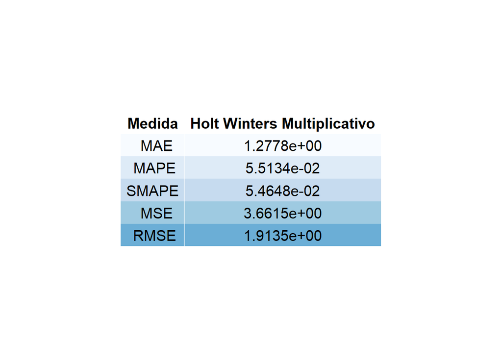

```r
mae_PromFHWM<-MAE(tsTemp, fhwm)
mape_PromFHWM<-MAPE(tsTemp, fhwm)
smape_PromFHWM<-SMAPE(tsTemp, fhwm)
mse_PromFHWM<-MSE(tsTemp, fhwm)
rmse_PromFHWM<-RMSE(tsTemp, fhwm)
medidas_PromFHWM<-matrix(c(mae_PromFHWM,mape_PromFHWM,smape_PromFHWM,mse_PromFHWM,rmse_PromFHWM))
rownames(medidas_PromFHWM)<-c("MAE","MAPE","SMAPE","MSE","RMSE")
colnames(medidas_PromFHWM)<-c("Holt Winters Multiplicativo" )
df_medidas_PromFHWM<-as.data.frame(medidas_PromFHWM)
tab_medidas_PromFHWM<-as.data.table(df_medidas_PromFHWM,keep.rownames=TRUE, keep.colnames=FALSE)
colnames(tab_medidas_PromFHWM)<-c("Medida","Holt Winters Multiplicativo")
ftab_medidas_PromFHWM<-format(tab_medidas_PromFHWM, digits=5,scientific=TRUE,big.mark=",",decimal.mark=".",small.mark=",",justify="right")
tem<-ttheme_minimal(base_colour = "black",base_size = 15,core=list(bg_params=list(fill=blues9,col=NA)))
grid.arrange(tableGrob(ftab_medidas_PromFHWM,theme=tem))
```

## Holt Winters Aditivo

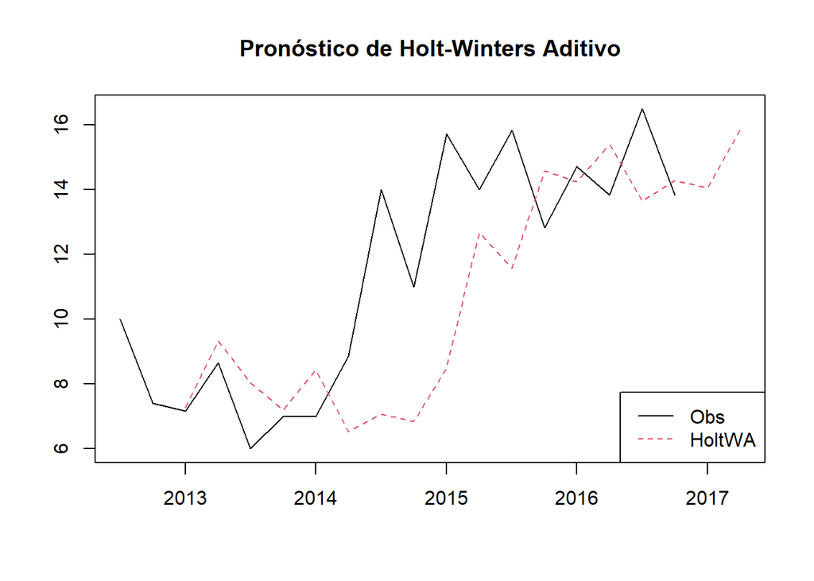

```r
y_ts1<-ts(data$meantemp,start=c(2012,3),frequency=4)
est_hwa1<-hw(y_ts1, h = 2, seasonal = c("additive"),level = c(80, 95),initial = c("optimal"), alpha = NULL, beta = NULL, gamma = NULL)
fhwa1<-est_hwa1$fitted
fhwa_ts1<-ts(fhwa1,start=c(2012,3),frequency=4)
fhwat_ts1<-rep(0,20)
for(t in 3:20) fhwat_ts1[t]<-fhwa_ts1[t-2]
for(t in 1:2) fhwat_ts1[t]<-NA
yt1<-rep(0,20)
for(t in 1:18) yt1[t]<-y_ts1[t]
for(t in 19:20) yt1[t]<-NA
yt_ts1<-ts(yt1,start=c(2012,3),frequency=4)
ts.plot(yt_ts1,fhwat_ts1,xlab=NULL,ylab=NULL, main = "Pronóstico de Holt-Winters Aditivo",lty=c(1:2),col=c(1,2))
legend(x="bottomright",legend=c("Obs","HoltWA"),col=c(1,2),lty=c(1,2))
```

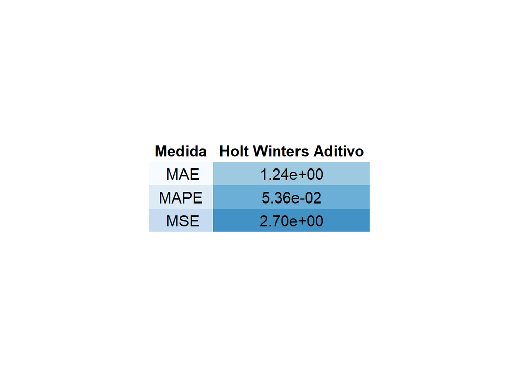

```r
mae_PromFHWA<-MAE(tsTemp, fhwa1)
mape_PromFHWA<-MAPE(tsTemp, fhwa1)
mse_PromFHWA<-MSE(tsTemp, fhwa1)


medidas_PromFHWA<-matrix(c(mae_PromFHWA,mape_PromFHWA,mse_PromFHWA))
rownames(medidas_PromFHWA)<-c("MAE","MAPE","MSE")
colnames(medidas_PromFHWA)<-c("Holt Winters Aditivo" )
df_medidas_PromFHWA<-as.data.frame(medidas_PromFHWA)
tab_medidas_PromFHWA<-as.data.table(df_medidas_PromFHWA,keep.rownames=TRUE, keep.colnames=FALSE)
colnames(tab_medidas_PromFHWA)<-c("Medida","Holt Winters Aditivo")
ftab_medidas_PromFHWA<-format(tab_medidas_PromFHWA, digits=3,scientific=TRUE,big.mark=",",decimal.mark=".",small.mark=",",justify="right")
tem<-ttheme_minimal(base_colour = "black",base_size = 15,core=list(bg_params=list(fill=blues9,col=NA)))
grid.arrange(tableGrob(ftab_medidas_PromFHWA,theme=tem))
```

Holt winters aditivo es el mejor porque sus errores son menores

# Conclusiones

## Pronostico

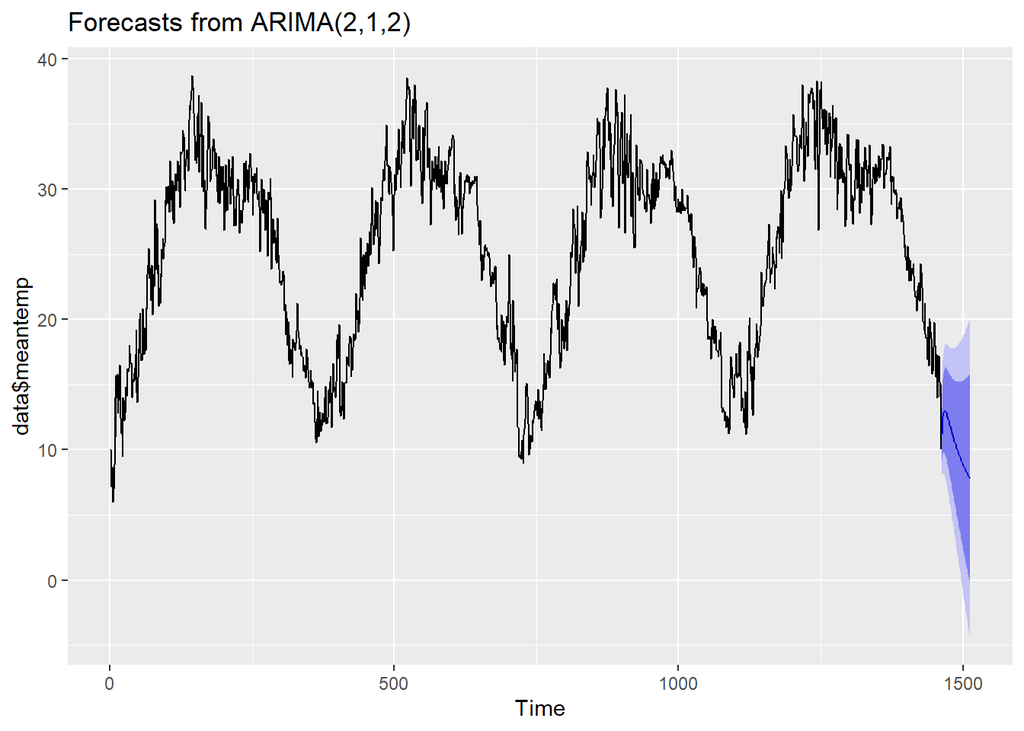

```r
pronostico <- forecast(modelo_ar1, h=50)
autoplot(pronostico)
```

```r
predict(pronostico, h=50)
```

```
##      Point Forecast      Lo 80    Hi 80        Lo 95    Hi 95
## 1463      11.220779  9.1820529 13.25951  8.102816346 14.33874
## 1464      12.019069  9.4486050 14.58953  8.087883249 15.95026
## 1465      12.520573  9.6658491 15.37530  8.154649533 16.88650
## 1466      12.813971  9.7813380 15.84660  8.175959106 17.45198
## 1467      12.961818  9.8043347 16.11930  8.132864006 17.79077
## 1468      13.008231  9.7541797 16.26228  8.031588918 17.98487
## 1469      12.984318  9.6491370 16.31950  7.883598864 18.08504
## 1470      12.912003  9.5039447 16.32006  7.699827571 18.12418
## 1471      12.806733  9.3297757 16.28369  7.489185658 18.12428
## 1472      12.679383  9.1348400 16.22393  7.258472482 18.10029
## 1473      12.537601  8.9250690 16.15013  7.012710097 18.06249
## 1474      12.386761  8.7047093 16.06881  6.755548815 18.01797
## 1475      12.230630  8.4767900 15.98447  6.489626872 17.97163
## 1476      12.071844  8.2434725 15.90021  6.216855198 17.92683
```

[output cut: 36 more lines]

$$y_t=m_t+s_t+u_t$$

$m_t:$ la mejor tendencia determinista basandonos en la que tiene menores erroes es el promedio ponderado w

$s_t:$ el mejor componente estacional determinista basdandonos en los errores es el de holt winters aditivo

$u_t:$ el proceso más optimo es el de ARIMA(2,1,2)